# ggplot2 wrapped 2025

Let it plot!  
Let it chart!  
Let it dataviz!

Welcome to your year in {ggplot2!}

[figure not shown]

> Interactive report built with love by {ggplot2wrapped} from Charlotte Hadley at GPCDS

GOT TO PLOT THEM ALL!

You used 32 out of 53 geoms from {ggplot2}!  
Mhm! That’s over 60%!  
Let’s look at your top used geoms!

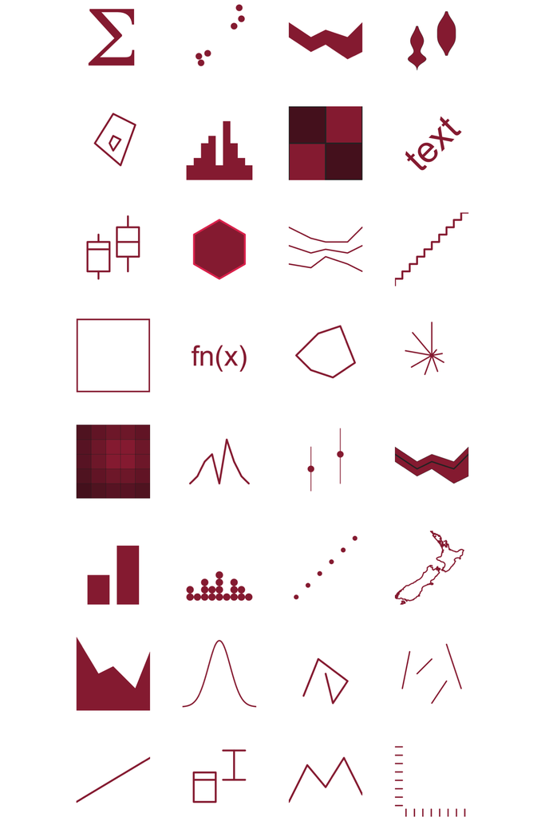

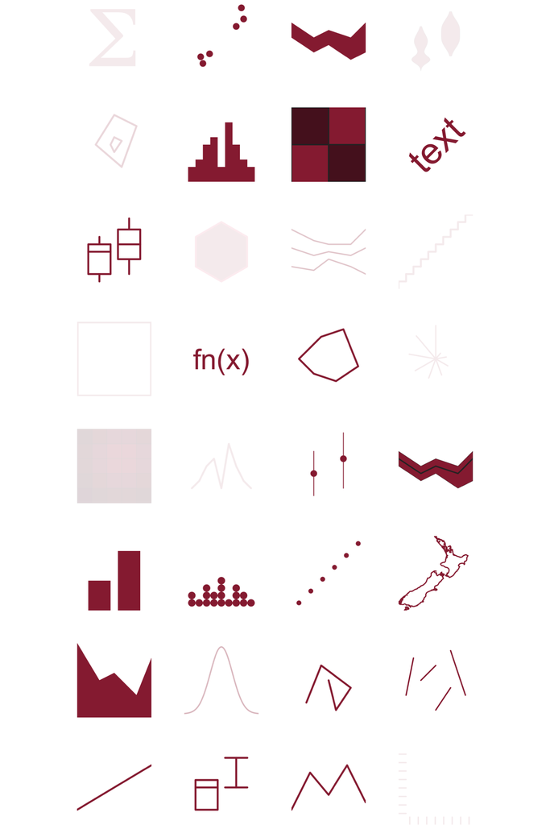

That was your most used geom in 2025! Let’s look at your other top geoms!

Shout out to geom_point

Ole! There are so many different ways to look at how your geoms were used across your smashing data visualisations. Maybe the easiest way is a **part-to-whole** story?

Looking at your *top 4 geoms* and lumping everything else together…

[interactive chart not shown]

> No surprises but your most used geom was also the geom that appeared in the most distinct files

[interactive chart not shown]

What a chart full year!  
In total 1,096 files were created that contained geoms!

Your busiest month(s) were November.  
These months accounted for 19% of your files with geoms!

Things look a lot different thinking about geom diversity!

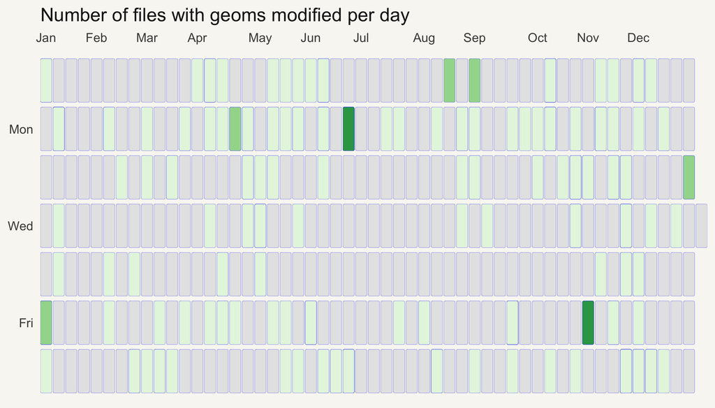

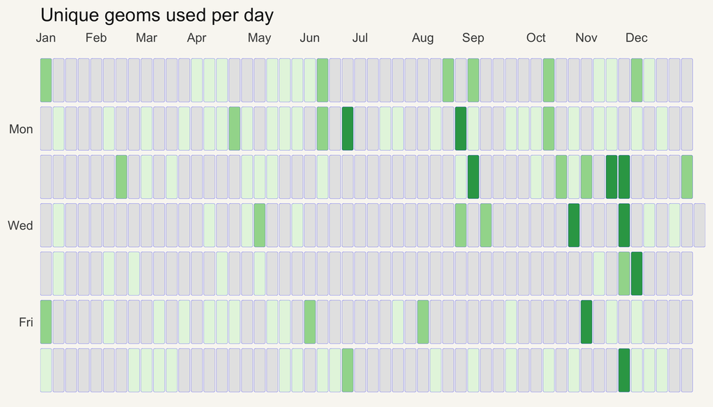

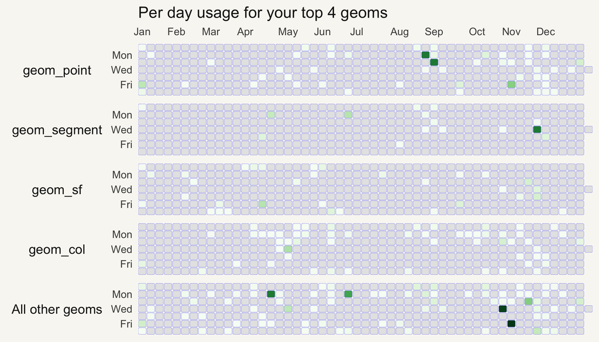

Well, that’s complicated! Let’s get into it!

Which geoms did you use together most often?

This *Venn Diagram* shows your top 3 most used geoms and how often you used them in the same code files

[interactive chart not shown]

That’s kind of interesting!

But wait! You used an **solid 32 unique geoms** - a Venn Diagram of that size would be a mess!

That’s because we’re not really making a straigh forward plot or chart - we’re visualising a graph! In graphs we are interested in the relationships and connections between *things*. You might be familiar with hairball-looking graph visualisations - which are just as difficult to extract meaning from as a Venn Diagram.

So, let’s use an **UpSet Chart** to look at your most inter-connected geoms in 2025

> **Please** move your cursor over the chart below - it’s very interactive.

[interactive chart not shown]

> We’ve thrown away some of your data to make this readable. Geoms only appear if they occur more than 10 times in your data and an interaction has to occur more than once

### Oh, wow! Tell me more about UpSet Charts

> Alexander Lex, Nils Gehlenborg, Hendrik Strobelt, Romain Vuillemot, Hanspeter Pfister. UpSet: Visualization of Intersecting Sets IEEE Transactions on Visualization and Computer Graphics (InfoVis), 20(12): 1983–1992, [doi:10.1109/TVCG.2014.2346248](https://doi.org.10.1109/TVCG.2014.2346248,%202014), 2014.

On to more fun things!

How can we talk about {ggplot2} without mentioning aesthetics?

All 4,308 times you used a geom they did their magic with either dataviz-level or geom-specific aes

Across all your geoms in 2025, 52% of the time you provided dataviz-level aesthetics.

Ohhh… but that chart mentions different packages?

The 2025 edition of the {ggplot2wrapped} report doesn’t focus on comparing package usage.

But if you take a look at our [documentation](https://charliejhadley.github.io/ggplot2wrapped/) you can analyse that data yourself

```r
# dataviz-level aesthetic
your_data |>
  ggplot() +
  aes(x = independent_variable,
      y = dependent_variable) +
  geom_point()

# geom-specific aes
your_data |>
  ggplot() +
  geom_point(aes(x = independent_variable,
      y = dependent_variable))
```

[interactive chart not shown]

Such fussy geoms!

Or such strong dataviz-level aesthetics!

[interactive chart not shown]

This might be the last pun?

Let’s wrap up looking at the arguments!

Just like all your data visualisations are different, your geom calls varied a lot!

[interactive chart not shown]

You might have noticed that’s not all your geoms 👀

That’s because 25% of the time you used geoms with zero arguments!

### We’re coming to the end of the report…

Here are some final statistics:

There’s a lot more you can do with the [{ggplot2} package](https://charliejhadley.github.io/ggplot2wrapped/) but we’ll sign off with what you were probably expecting and we’d hate to let you down:

[interactive chart not shown]

How was this built?

That was fun! Next year there’ll be more, this package and report was thrown together in a week

This package and report depends on several tools from within R:

- Geom usage was analysed using Abstract Syntax Trees via the {astgrepr} package
- Static charts were built with {ggplot2}
- Interactive charts were built with a mixture of {highcharter} and {upsetjs}
- The report itself was written using a Quarto extension called [Closeread](https://closeread.dev/) for scrollytelling

> The report was built by me - Charlotte Hadley from gpcds.com.

> I can be [found on LinkedIn](https://www.linkedin.com/in/charliejhadley/) if that’s your thing.

> I would genuinely love to see you share your {ggplot2wrapped} reports and charts.

> There’s **lots** more you can do yourself with the `add_geom_usage_to_files()` function. Share what you build and consider contributing to the package, https://github.com/charliejhadley/ggplot2wrapped.